# Loading and Preprocessing the Data

```python
import pandas as pd
from sklearn.model_selection import train_test_split
from sklearn.preprocessing import LabelEncoder

# Load data
url = "https://storage.googleapis.com/adsp-nlp-open/elsevier-oa-cc-by/abstracts.json"
data = pd.read_json(url, orient="records")

# Check the data structure
print(data.head())
```

```
              doc_id                                              title  \
0  S0960076016300644  Sterols and oxysterols in plasma from Smith-Le...
1  S1471492219301369  The Uncertainty Surrounding the Burden of Post...
2  S2405580815000801  Low-mass molecular dynamics simulation for con...
3  S0142961216305853  Modulation of the molecular arrangement in art...
4  S0003682X1500242X  Validation of the blocked force method for var...

                                            abstract    subject
0  Smith-Lemli-Opitz syndrome (SLOS) is a severe ...   phys_sci
1  Post-acute consequences currently form a signi...  healh_sci
2  It has been reported recently that classical, ...   phys_sci
3  The transfer of material from phospholipid-coa...  engi_tech
4  Vibro-acoustic source characterization is an e...   phys_sci
```

```python
data['subject'].value_counts()
```

```
subject
phys_sci     13048
engi_tech     9211
healh_sci     7633
life_sci      5651
soc_sci       3143
Name: count, dtype: int64
```

```python
# Set up pandas to display the full content of columns
pd.set_option('display.max_columns', None)  # Show all columns
pd.set_option('display.width', None)        # Set no limit on the display width
pd.set_option('display.max_colwidth', None) # Show full content of each column


print(data.iloc[0])
```

```
doc_id                                                                                                                                                                                                                                                                                                      …
title                                                                                                                                                                                                                                                                                                       …
abstract    Smith-Lemli-Opitz syndrome (SLOS) is a severe autosomal recessive disorder resulting from defects in the cholesterol synthesising enzyme 7-dehydrocholesterol reductase (Δ7-sterol reductase, DHCR7, EC 1.3.1.21) leading to a build-up of the cholesterol precursor 7-dehydrocholesterol (7-DHC…
subject                                                                                                                                                                                                                                                                                                     …
Name: 0, dtype: object
```

```python
# Using both title and abstract for modeling
data['text'] = data['title'] + ' ' + data['abstract']
```

```python
import spacy
from tqdm import tqdm

# Load the spaCy model
nlp = spacy.load("en_core_web_sm")

# Provided clean_text function
def clean_text(corpus, spacy_pipeline, n_proc=2, batch_size=1000):
    """
    Cleans a sequence of text by applying some simple processing techniques.

    Args:
        corpus (Iterable): a sequence of text to be processed
        spacy_pipeline: the Spacy pipeline object for processing text
        n_proc (int): the number of processors to use for parallel processing
        batch_size (int): the number of texts to process in a single batch

    Returns:
        clean_sequence (list): a cleaned version of the original text
    """
    # container to store cleaned documents
    corpus_clean = []

    for doc in spacy_pipeline.pipe(
        corpus,
        disable=["ner"],
        n_process=n_proc,
        batch_size=batch_size
    ):

        # container for cleaned document tokens
        doc_tokens = [
            token.lemma_.lower()
            for token in doc
            if not token.is_stop and token.is_alpha
        ]

        # recombining tokens into a string
        clean_doc = " ".join(doc_tokens)

        corpus_clean.append(clean_doc)

    return corpus_clean
```

```python
# Preprocess the Text Data Using the clean_text Function
# Apply the cleaning function to the data

data["n_tokens"] = [len(text.split()) for text in data["text"]]
data['text_clean'] = clean_text(
    corpus=data["text"].tolist(),
    spacy_pipeline=nlp
)

# Verify the cleaned text
data.head()
```

|  | doc_id | title | abstract | subject | text | n_tokens | text_clean |
| --- | --- | --- | --- | --- | --- | --- | --- |
| 0 | S0960076016300644 | Sterols and oxysterols in plasma from Smith-Lemli-Opitz syndrome patients | Smith-Lemli-Opitz syndrome (SLOS) is a severe autosomal recessive disorder resulting from defects in the cholesterol synthesising enzyme 7-dehydrocholesterol reductase (Δ7-sterol reductase, DHCR7, EC … | phys_sci | Sterols and oxysterols in plasma from Smith-Lemli-Opitz syndrome patients Smith-Lemli-Opitz syndrome (SLOS) is a severe autosomal recessive disorder resulting from defects in the cholesterol synthesis… | 139 | sterol oxysterol plasma smith lemli opitz syndrome patient smith lemli opitz syndrome slos severe autosomal recessive disorder result defect cholesterol synthesise enzyme dehydrocholesterol reductase … |
| 1 | S1471492219301369 | The Uncertainty Surrounding the Burden of Post-acute Consequences of Dengue Infection | Post-acute consequences currently form a significant component of the dengue disability-adjusted life year (DALY) burden estimates. However, there is considerable uncertainty regarding the incidence, … | healh_sci | The Uncertainty Surrounding the Burden of Post-acute Consequences of Dengue Infection Post-acute consequences currently form a significant component of the dengue disability-adjusted life year (DALY) … | 58 | uncertainty surround burden post acute consequences dengue infection post acute consequence currently form significant component dengue disability adjust life year daly burden estimate considerable un… |
| 2 | S2405580815000801 | Low-mass molecular dynamics simulation for configurational sampling enhancement: More evidence and theoretical explanation | It has been reported recently that classical, isothermal-isobaric molecular dynamics (NTP MD) simulations at a time step of 1.00fs of the standard-mass time (δt=1.00fssmt) and a temperature of ≤340K u… | phys_sci | Low-mass molecular dynamics simulation for configurational sampling enhancement: More evidence and theoretical explanation It has been reported recently that classical, isothermal-isobaric molecular d… | 196 | low mass molecular dynamic simulation configurational sampling enhancement evidence theoretical explanation report recently classical isothermal isobaric molecular dynamic ntp md simulation time step … |
| 3 | S0142961216305853 | Modulation of the molecular arrangement in artificial and biological membranes by phospholipid-shelled microbubbles | The transfer of material from phospholipid-coated microbubbles to cell membranes has been hypothesized to play a role in ultrasound-mediated drug delivery. In this study, we employed quantitative fluo… | engi_tech | Modulation of the molecular arrangement in artificial and biological membranes by phospholipid-shelled microbubbles The transfer of material from phospholipid-coated microbubbles to cell membranes has… | 153 | modulation molecular arrangement artificial biological membrane phospholipid shell microbubble transfer material phospholipid coat microbubble cell membrane hypothesize play role ultrasound mediate dr… |
| 4 | S0003682X1500242X | Validation of the blocked force method for various boundary conditions for automotive source characterization | Vibro-acoustic source characterization is an essential task in vehicle development to enable prediction of receiver response. For structure-borne noise, the interface forces in multiple degrees of fre… | phys_sci | Validation of the blocked force method for various boundary conditions for automotive source characterization Vibro-acoustic source characterization is an essential task in vehicle development to enab… | 297 | validation block force method boundary condition automotive source characterization vibro acoustic source characterization essential task vehicle development enable prediction receiver response struct… |

```python
# Encoding the target labels
label_encoder = LabelEncoder()
data['label'] = label_encoder.fit_transform(data['subject'])
```

```python
data.head(3)
```

|  | doc_id | title | abstract | subject | text | n_tokens | text_clean | label |
| --- | --- | --- | --- | --- | --- | --- | --- | --- |
| 0 | S0960076016300644 | Sterols and oxysterols in plasma from Smith-Lemli-Opitz syndrome patients | Smith-Lemli-Opitz syndrome (SLOS) is a severe autosomal recessive disorder resulting from defects in the cholesterol synthesising enzyme 7-dehydrocholesterol reductase (Δ7-sterol reductase, DHCR7, EC … | phys_sci | Sterols and oxysterols in plasma from Smith-Lemli-Opitz syndrome patients Smith-Lemli-Opitz syndrome (SLOS) is a severe autosomal recessive disorder resulting from defects in the cholesterol synthesis… | 139 | sterol oxysterol plasma smith lemli opitz syndrome patient smith lemli opitz syndrome slos severe autosomal recessive disorder result defect cholesterol synthesise enzyme dehydrocholesterol reductase … | 3 |
| 1 | S1471492219301369 | The Uncertainty Surrounding the Burden of Post-acute Consequences of Dengue Infection | Post-acute consequences currently form a significant component of the dengue disability-adjusted life year (DALY) burden estimates. However, there is considerable uncertainty regarding the incidence, … | healh_sci | The Uncertainty Surrounding the Burden of Post-acute Consequences of Dengue Infection Post-acute consequences currently form a significant component of the dengue disability-adjusted life year (DALY) … | 58 | uncertainty surround burden post acute consequences dengue infection post acute consequence currently form significant component dengue disability adjust life year daly burden estimate considerable un… | 1 |
| 2 | S2405580815000801 | Low-mass molecular dynamics simulation for configurational sampling enhancement: More evidence and theoretical explanation | It has been reported recently that classical, isothermal-isobaric molecular dynamics (NTP MD) simulations at a time step of 1.00fs of the standard-mass time (δt=1.00fssmt) and a temperature of ≤340K u… | phys_sci | Low-mass molecular dynamics simulation for configurational sampling enhancement: More evidence and theoretical explanation It has been reported recently that classical, isothermal-isobaric molecular d… | 196 | low mass molecular dynamic simulation configurational sampling enhancement evidence theoretical explanation report recently classical isothermal isobaric molecular dynamic ntp md simulation time step … | 3 |

```python
# Splitting the dataset using the cleaned text
X_train, X_test, y_train, y_test = train_test_split(data['text_clean'], data['label'], test_size=0.2, random_state=42)

print(
    f"{X_train.shape=}",
    f"{X_test.shape=}",
    sep="\n"
)
```

```
X_train.shape=(30948,)
X_test.shape=(7738,)
```

# Feature Extraction using TF-IDF

```python
# Convert the cleaned text into numerical features using the TfidfVectorizer

from sklearn.feature_extraction.text import TfidfVectorizer

# Using TF-IDF Vectorizer
tfidf_vectorizer = TfidfVectorizer(max_features=10000, ngram_range=(1, 2), stop_words='english')
X_train_tfidf = tfidf_vectorizer.fit_transform(X_train)
X_test_tfidf = tfidf_vectorizer.transform(X_test)

# Check the shape of the transformed data
print(X_train_tfidf.shape, X_test_tfidf.shape)
```

```
(30948, 10000) (7738, 10000)
```

# Training 4 Models

# Multinomial Naive Bayes, Logistic Regression, SVM, and Random Forest

Try four non-deep learning models.

Multinomial Naive Bayes: Prof demonstrated its mechanisms during class so I wanted to try.

Logistic Regression: Simple, interpretable, and fast for both training and inference.

Support Vector Machine (SVM): Effective in high-dimensional spaces, can be slower to train but works well for text data.

Random Forest: A tree-based ensemble method, generally fast for training and inference.

### Multinomial Naive Bayes

```python
from sklearn.naive_bayes import MultinomialNB
from sklearn.metrics import classification_report
from sklearn.metrics import accuracy_score

# Train Multinomial Naive Bayes
nb_model = MultinomialNB()
nb_model.fit(X_train_tfidf, y_train)

# Predict and evaluate
y_pred_nb = nb_model.predict(X_test_tfidf)
print("Multinomial Naive Bayes:\n", classification_report(y_test, y_pred_nb))
print("Accuracy:", accuracy_score(y_test, y_pred_nb))
```

```
Multinomial Naive Bayes:
               precision    recall  f1-score   support

           0       0.69      0.83      0.75      1809
           1       0.74      0.78      0.76      1525
           2       0.67      0.44      0.53      1191
           3       0.66      0.63      0.65      2578
           4       0.59      0.66      0.62       635

    accuracy                           0.68      7738
   macro avg       0.67      0.67      0.66      7738
weighted avg       0.68      0.68      0.67      7738

Accuracy: 0.6792452830188679
```

### Logistic Regression

```python
from sklearn.linear_model import LogisticRegression

# Train Logistic Regression
log_reg = LogisticRegression(max_iter=1000)
log_reg.fit(X_train_tfidf, y_train)

# Predict and evaluate
y_pred_log_reg = log_reg.predict(X_test_tfidf)
print("Logistic Regression:\n", classification_report(y_test, y_pred_log_reg))
print("Accuracy:", accuracy_score(y_test, y_pred_log_reg))
```

```
Logistic Regression:
               precision    recall  f1-score   support

           0       0.76      0.79      0.77      1809
           1       0.78      0.79      0.78      1525
           2       0.69      0.56      0.62      1191
           3       0.68      0.74      0.71      2578
           4       0.74      0.65      0.69       635

    accuracy                           0.73      7738
   macro avg       0.73      0.71      0.72      7738
weighted avg       0.73      0.73      0.72      7738

Accuracy: 0.726027397260274
```

### Support Vector Machine (SVM)

```python
from sklearn.svm import SVC

# Train SVM
svm_model = SVC(kernel='linear')
svm_model.fit(X_train_tfidf, y_train)

# Predict and evaluate
y_pred_svm = svm_model.predict(X_test_tfidf)
print("Support Vector Machine:\n", classification_report(y_test, y_pred_svm))
print("Accuracy:", accuracy_score(y_test, y_pred_svm))
```

```
Support Vector Machine:
               precision    recall  f1-score   support

           0       0.75      0.80      0.77      1809
           1       0.79      0.79      0.79      1525
           2       0.68      0.56      0.61      1191
           3       0.69      0.73      0.71      2578
           4       0.73      0.67      0.70       635

    accuracy                           0.73      7738
   macro avg       0.73      0.71      0.72      7738
weighted avg       0.72      0.73      0.72      7738

Accuracy: 0.7255104678211424
```

### Random Forest

```python
from sklearn.ensemble import RandomForestClassifier

# Train Random Forest
rf_model = RandomForestClassifier(n_estimators=100)
rf_model.fit(X_train_tfidf, y_train)

# Predict and evaluate
y_pred_rf = rf_model.predict(X_test_tfidf)
print("Random Forest:\n", classification_report(y_test, y_pred_rf))
print("Accuracy:", accuracy_score(y_test, y_pred_rf))
```

```
Random Forest:
               precision    recall  f1-score   support

           0       0.70      0.78      0.74      1809
           1       0.74      0.81      0.77      1525
           2       0.72      0.30      0.43      1191
           3       0.60      0.73      0.66      2578
           4       0.72      0.46      0.56       635

    accuracy                           0.67      7738
   macro avg       0.70      0.62      0.63      7738
weighted avg       0.68      0.67      0.66      7738

Accuracy: 0.6700697854742828
```

# Evaluate and Compare Models

### Based on "When searching, users have a preference for not being shown articles that are irrelevant to their search", **precision** is a crucial metric, then f1-score.

### Multinomial Naive Bayes and Logistic Regression are generally fast for both training and inference.

### SVM is slow to train, especially with large data, but moderately fast during inference.

### Random Forest is slower to train but provides reasonable inference times.

### Logistic Regression and Support Vector Machine (SVM) performs the best in terms of precision and f1-score.

**Multinomial Naive Bayes (NB)**

Strengths: Fast, handles high-dimensional text data well.

Shortcomings: Assumes feature independence, which leads to lower precision and recall in complex text patterns.

**Logistic Regression**

Strengths: Simple, interpretable, effective with high-dimensional, linearly separable data.

Shortcomings: Struggles with non-linear relationships and requires feature scaling.

**Support Vector Machine**

Strengths: Excellent for high-dimensional data, handles complex patterns well.

Shortcomings: Slow to train and requires careful hyperparameter tuning.

**Random Forest**

Strengths: Good for non-linear relationships, reduces overfitting.

Shortcomings: Less effective with high-dimensional sparse data like text, slower inference.

**Logistic Regression and SVM performed best due to their ability to handle high-dimensional text data efficiently.**

# Troubleshoot misclassifications with confusion matrix

```python
import matplotlib.pyplot as plt
from sklearn.metrics import classification_report, ConfusionMatrixDisplay
```

[output not shown]

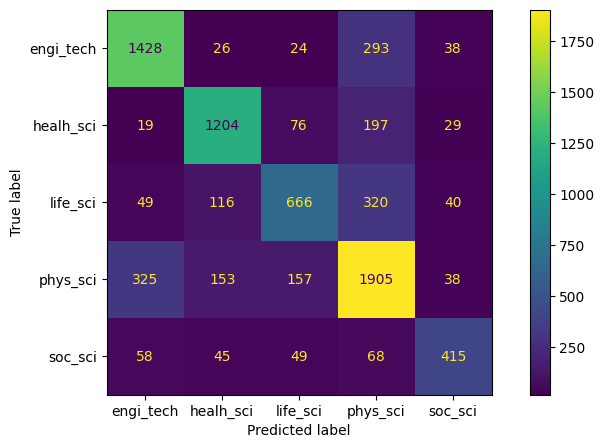

```python
#Confusion Matrix of Logistic Regression method
fig, ax = plt.subplots(figsize=(10, 5))
ConfusionMatrixDisplay.from_predictions(y_test, y_pred_log_reg, ax=ax)

ax.xaxis.set_ticklabels(label_encoder.classes_)
ax.yaxis.set_ticklabels(label_encoder.classes_)
```

[output not shown]

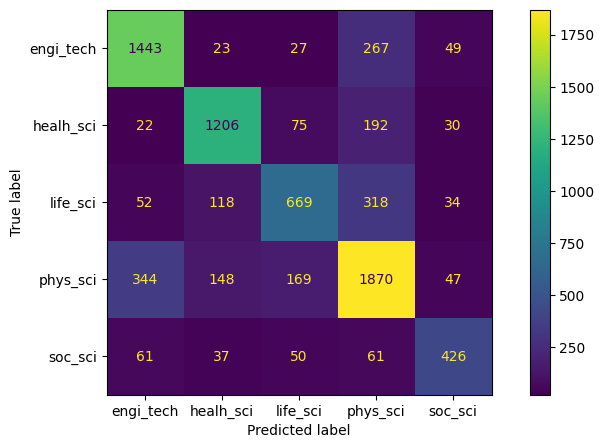

```python
#Confusion Matrix for SVM method
fig, ax = plt.subplots(figsize=(10, 5))
ConfusionMatrixDisplay.from_predictions(y_test, y_pred_svm, ax=ax)

ax.xaxis.set_ticklabels(label_encoder.classes_)
ax.yaxis.set_ticklabels(label_encoder.classes_)
```

# Examples of where the model is falling short and provide an explanation for might be happening

### Potential issues might include overlapping topics or ambiguous article abstracts.

### Examing the most import features can give us insight into how our model can be improved. **Perhaps there are misleading words we can remove.**

### To extract the top 30 features (terms) for each class from my Logistic Regression model, look at the model's coefficients.

### The coefficients indicate the importance of each feature (word) in predicting the target class.

```python
import numpy as np

# Get the feature names from the TF-IDF vectorizer
features = np.array(tfidf_vectorizer.get_feature_names_out())

# Get the coefficients (importance of each feature) from the Logistic Regression model
coefficients = log_reg.coef_

# Number of top features to extract
N = 30

# Loop over each class in the model
for i, class_ in enumerate(log_reg.classes_):
    # Sort the coefficients for the class to get the indices of top positive features
    top_n_features = np.argsort(coefficients[i])[-N:]

    # Print the class label and the top N features
    print(f"Class {label_encoder.inverse_transform([class_])[0]}:")
    print(f"Top {N} features: {[features[idx] for idx in top_n_features]}")
    print("\n")
```

```
Class engi_tech:
Top 30 features: ['gas', 'concrete', 'performance', 'code', 'crack', 'algorithm', 'device', 'crash', 'solar', 'pv', 'heat', 'oa', 'osteoarthritis', 'power', 'surface', 'combustion', 'material', 'load', 'catalyst', 'electricity', 'propose', 'safety', 'accident', 'user', 'engineering', 'alloy', 'softw…


Class healh_sci:
Top 30 features: ['cholera', 'disease', 'ci', 'associate', 'symptom', 'year', 'image', 'transmission', 'adolescent', 'antibody', 'isolate', 'anthelmintic', 'host', 'tick', 'surgery', 'immunization', 'vaccination', 'photoacoustic', 'forensic', 'surgical', 'virus', 'introduction', 'infection', 'health…


Class life_sci:
Top 30 features: ['pharmaceutical', 'bird', 'leaf', 'biomass', 'neuroscience', 'cortical', 'shelf', 'satellite', 'neuron', 'landsat', 'neuronal', 'aquaculture', 'trial', 'toxicity', 'fish', 'dry', 'animal', 'ecosystem service', 'cortex', 'food', 'tablet', 'habitat', 'formulation', 'brain', 'conserva…


Class phys_sci:
Top 30 features: ['algebra', 'mars', 'substrate', 'determination', 'proteomic', 'water', 'parameter', 'crystal', 'alfa', 'decay', 'pollutant', 'equation', 'obtain', 'lhc', 'mantle', 'climate service', 'diabete', 'sludge', 'photon', 'enzyme', 'sediment', 'pku', 'detector', 'disaster', 'modification',…


Class soc_sci:
Top 30 features: ['crisis', 'bank', 'finding', 'theory', 'income', 'political', 'price', 'financial', 'rural', 'preference', 'holocene', 'student', 'account', 'teacher', 'century', 'economy', 'inequality', 'child', 'infant', 'draw', 'english', 'participant', 'tourism', 'evidence', 'intelligence', 'e…
```

### We can print out more features. Then remove the misleading/overlapping features under Class soc_sci to improve its score.